# The structural stability of nested experimental plankton system

Longxiao

packages:

```r
library("readxl")
library("dplyr")
library("ggplot2")
library("patchwork")
library("RColorBrewer")
library("deSolve")
```

set directions

```r
# raw data direction
if (!dir.exists("../data")) {
  dir.create("../data", recursive = TRUE)
}

# output direction
if (!dir.exists("../output")) {
  dir.create("../output", recursive = TRUE)
}

# plot direction
if (!dir.exists("../plot")) {
  dir.create("../plot", recursive = TRUE)
}
```

```r
data_dir <- "../data"
output_dir <- "../output"
plot_dir <- "../plot"
```

# Read data and preliminary operation

read data sheet

```r
file_path <- file.path(data_dir, "WP2_2_clean.xlsx")
data<-read_xlsx(file_path, sheet = "Sheet1")

# data <- data %>% select(-date, -grazer_treatment,-diversity_level,-comment)

colnames(data)
```

```
 [1] "identifier"               "system"
 [3] "experiment"               "date"
 [5] "day"                      "grazer_treatment"
 [7] "nutrient_treatment"       "species_richness"
 [9] "diversity_level"          "ID_bucket"
[11] "number_bucket"            "number_bag"
[13] "name"                     "group"
[15] "species"                  "Fix_Area_bag"
[17] "Chla_bag"                 "Fix_Area_recalc"
[19] "Fix_Area_accrual"         "Chla_recalc"
[21] "Fv/Fm"                    "ABS/RC"
[23] "Eto/RC"                   "GR"
[25] "GR_total"                 "Fix_Area_recalc_expected"
[27] "RYi_Fix_Area"             "RYi_Fix_Area_accrual"
[29] "PP"                       "filteredVol_PP_ml"
[31] "PP_µg/L"                  "PP_µmol/L"
[33] "%N"                       "%C"
[35] "filteredVol_CN_ml"        "N_mg/L"
[37] "C_mg/L"                   "N_µmol/L"
[39] "C_µmol/L"                 "C:N"
[41] "C:P"                      "N:P"
[43] "C_accrual"                "RYi_C"
[45] "C:Fix_Area"               "Fix_Area:N"
[47] "Fix_Area:P"               "cells/L_species"
[49] "vol/cell_µm3"             "source"
[51] "biovolume_µm3/L_species"  "biovolume_mm3/L_species"
[53] "biovol_perc_species"      "cells/L_total"
[55] "biovolume_mm3/L_total"    "comment"
```

take necessary columns:

time, treatment class, species, labels and group, population size (Fix_Area_Recalc)

And in each treatment, bucket, we sum the same species up.

```r
df <- data %>% select(day, nutrient_treatment, species_richness, number_bucket, number_bag, group, species, Fix_Area_recalc)
df <- df[df$species!="Medium",]
df$number_bag <- as.factor(df$number_bag)
df$species <- as.factor(df$species)
df$Fix_Area_recalc <- as.numeric(as.character(df$Fix_Area_recalc))

df_total <- df %>%
  group_by(day, nutrient_treatment, species_richness, number_bucket, group, species) %>%
  summarise(Fix_Area_recalc = sum(Fix_Area_recalc, na.rm = TRUE), .groups = "drop")

colnames(df)
```

```
[1] "day"                "nutrient_treatment" "species_richness"
[4] "number_bucket"      "number_bag"         "group"
[7] "species"            "Fix_Area_recalc"
```

# Basic plot

We then set a project from species to color:

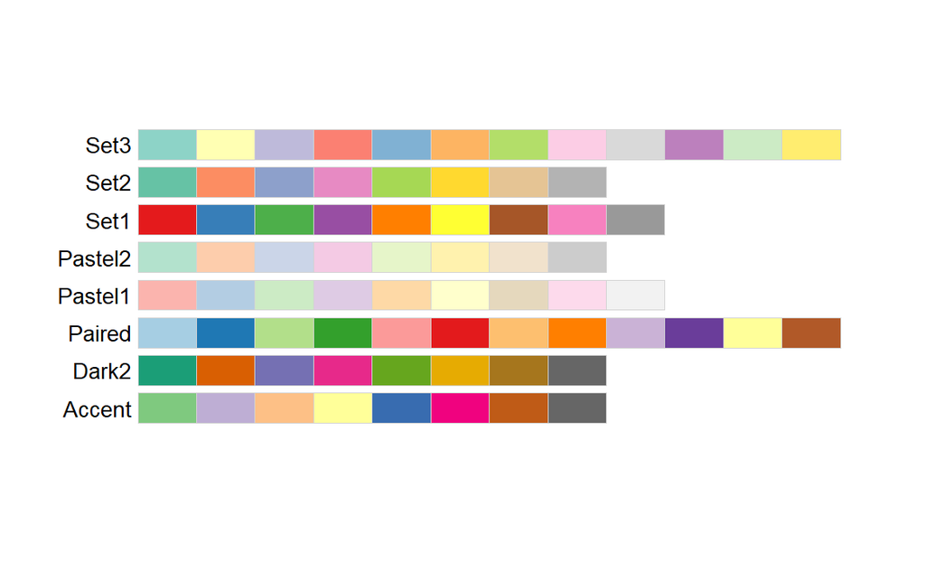

```r
display.brewer.all(type = "qual")
```

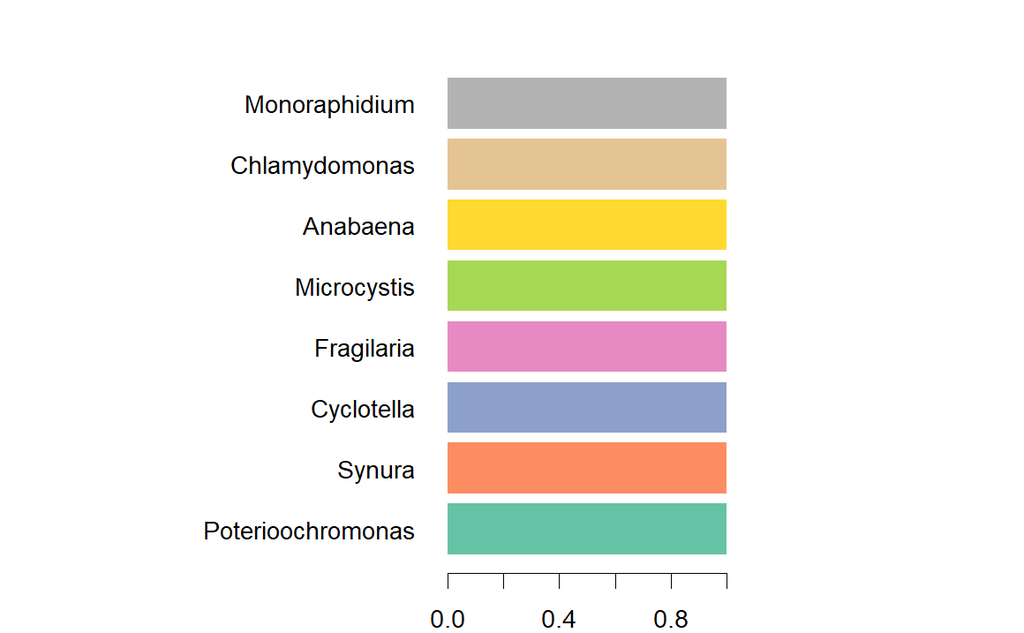

```r
species <- unique(df$species)

species_colors <- brewer.pal(n = length(species), name = "Set2")
names(species_colors) <- species

par(mar = c(2, 15, 2, 10))

barplot(
  height = rep(1, length(species_colors)),
  names.arg = names(species_colors),
  col = species_colors,
  border = NA,
  horiz = TRUE,
  las = 1
)
```

Now, the species is related to the color shown above.

Then we divide the data by treatment: N pulse, N limited

```r
df_Npulse <- df[df$nutrient_treatment == "N pulse",]
df_Nlimited <- df[df$nutrient_treatment == "N limited",]
```

Then split the data by species richness as well as bucket.

```r
split_bucket <- function(df) {
  return(lapply(split(df, df$species_richness), function(sub_df){
    split(sub_df, sub_df$number_bucket)
  }))
}

draw_splited_bucket <- function(df){

  data_list <- split_bucket(df)

  df_total <- df %>%
    group_by(day, nutrient_treatment, species_richness, number_bucket, group, species) %>%
    summarise(Fix_Area_recalc = mean(Fix_Area_recalc, na.rm = TRUE), .groups = "drop")

  sum_list <- split_bucket(df_total)

  plot_list <- list()
  sum_plot_list <- list()

  dummy <- data.frame(
    species = factor(species, levels = species),
    day = NA_real_,
    Fix_Area_recalc = NA_real_,
    number_bag = NA_real_
    )

  plot_geoms <- list(
    geom_line(linewidth = 1.2, show.legend = FALSE),
    geom_point(size = 2, show.legend = FALSE)
  )

  dummy_legend <- list(
    geom_line(
        data = dummy,
        aes(x = day, y = Fix_Area_recalc, color = species),
        linewidth = 1.2,
        alpha = 0,
        show.legend = TRUE,
        na.rm = TRUE
      )
  )

  plot_theme <- list(
    theme_minimal(),
    theme(
      axis.title = element_blank(),
      axis.ticks = element_blank()
    )
  )

  species_scale <- list(
    scale_color_manual(
      name = "Species",
      values = species_colors,
      drop = FALSE,
      guide = guide_legend(
        override.aes = list(alpha = 1, size = 1,
                            linetype = 1, shape = 16)
      )
    )
  )

  for (richness in names(data_list)) {
    p_richness_list <- list()
    s_richness_list <- list()
    for (bucket in names(data_list[[richness]])) {

      p1 <- ggplot(data_list[[richness]][[bucket]],
                 aes(x = day, y = Fix_Area_recalc,
                     group = number_bag, color = species)) +
        plot_geoms+
        plot_theme+
        dummy_legend+
        species_scale+
        labs(title = bucket)

      p_richness_list[[bucket]]<-p1

      p_sum<- ggplot(sum_list[[richness]][[bucket]],
               aes(x = day,
                   y = Fix_Area_recalc,
                   color = species)) +
        plot_geoms+
        plot_theme+
        dummy_legend+
        species_scale+
        labs(title = bucket)

      s_richness_list[[bucket]]<-p_sum
    }
    plot_list[[richness]]<- p_richness_list
    sum_plot_list[[richness]] <- s_richness_list
  }
  return(list(
    data_list,
    sum_list,
    plot_list,
    sum_plot_list
  ))
}

draw_Npulse <- draw_splited_bucket(df_Npulse)
Npulse_list <- draw_Npulse[[1]]
Npulse_sum <- draw_Npulse[[2]]
Npulse_plots <- draw_Npulse[[3]]
Npulse_sumplots <- draw_Npulse[[4]]

draw_Nlimited <- draw_splited_bucket(df_Nlimited)
Nlimited_list <- draw_Nlimited[[1]]
Nlimited_sum <- draw_Nlimited[[2]]
Nlimited_plots <- draw_Nlimited[[3]]
Nlimited_sumplots <- draw_Nlimited[[4]]
```

Now, each experiment is organized in a table. _list is the list of all experiment, _sum is the sum of each species, plots is the population size change plot, as well as sumplot is the plot of sum species population (or average). For example:

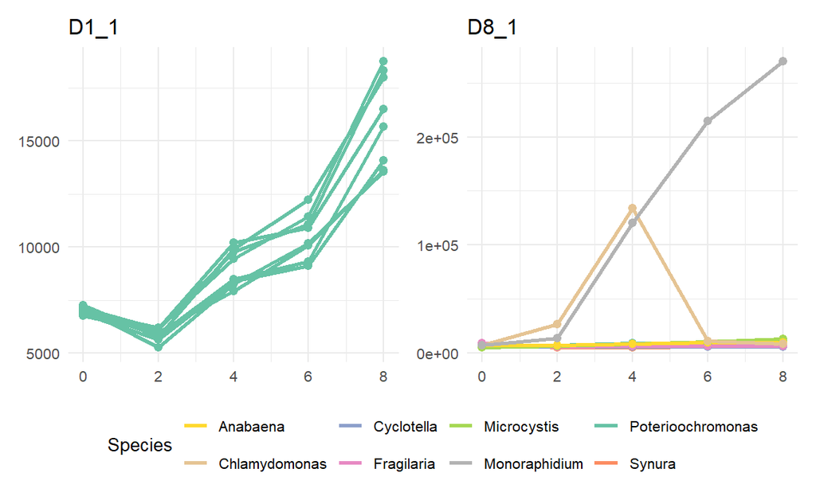

```r
(Npulse_plots[["1"]][["D1_1"]]|Npulse_plots[["8"]][["D8_1"]])+
  plot_layout(guides = 'collect') &
  theme(legend.position = "bottom")
```

We first show the single species case.

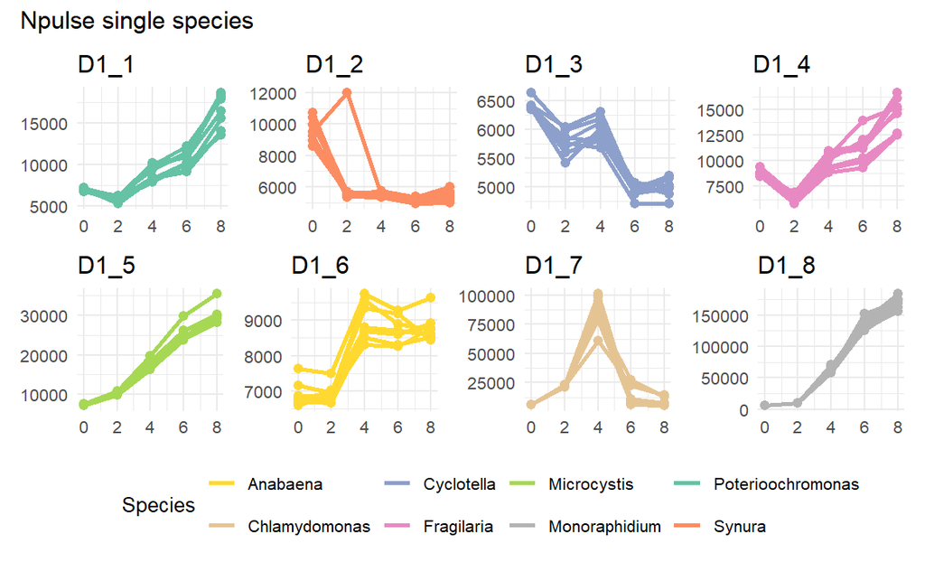

```r
draw_all_species <- function(draw_list){
  (draw_list[["1"]][["D1_1"]] | draw_list[["1"]][["D1_2"]] | draw_list[["1"]][["D1_3"]] | draw_list[["1"]][["D1_4"]])/
  (draw_list[["1"]][["D1_5"]] | draw_list[["1"]][["D1_6"]] | draw_list[["1"]][["D1_7"]] | draw_list[["1"]][["D1_8"]]) +
  plot_layout(guides = 'collect') &
  theme(legend.position = "bottom")
}
draw_all_species(Npulse_plots)&
  plot_annotation(
    title = "Npulse single species"
  )
```

Compare to the Nlimited case:

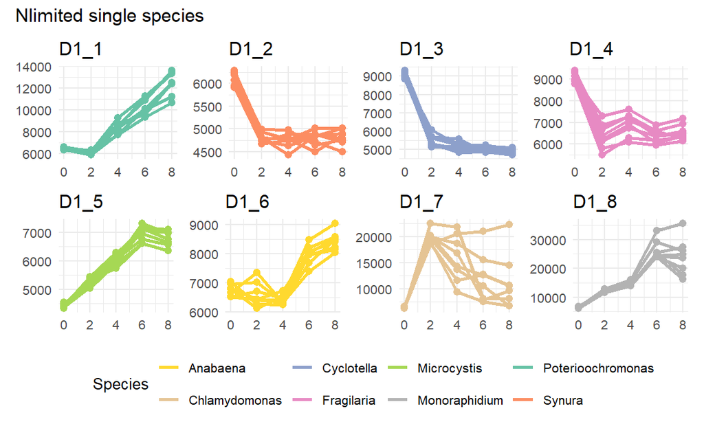

```r
draw_all_species(Nlimited_plots)&
  plot_annotation(
    title = "Nlimited single species"
  )
```

Then we plot the population change in co-cultivate cases:

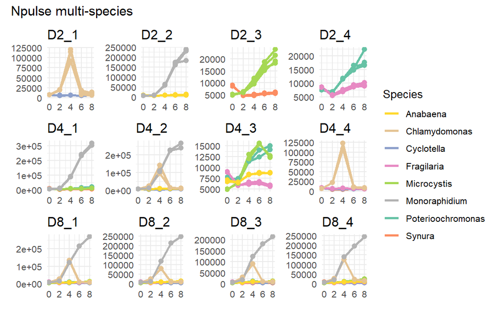

```r
draw_multi_species <- function(draw_list){
  (draw_list[["2"]][["D2_1"]] | draw_list[["2"]][["D2_2"]] | draw_list[["2"]][["D2_3"]] | draw_list[["2"]][["D2_4"]]) /
    (draw_list[["4"]][["D4_1"]] | draw_list[["4"]][["D4_2"]] | draw_list[["4"]][["D4_3"]] | draw_list[["4"]][["D4_4"]]) /
    (draw_list[["8"]][["D8_1"]] | draw_list[["8"]][["D8_2"]] | draw_list[["8"]][["D8_3"]] | draw_list[["8"]][["D8_4"]])+
  plot_layout(guides = 'collect') &
  theme(legend.position = "right")
}
draw_multi_species(Npulse_plots)&
  plot_annotation(
    title = "Npulse multi-species"
  )
```

Species Chlamydomonas (7) and Monoraphidium (8) shows a much higher population size compared to others, and their changing trend seems keep the same. We may need to rescale this two species later.

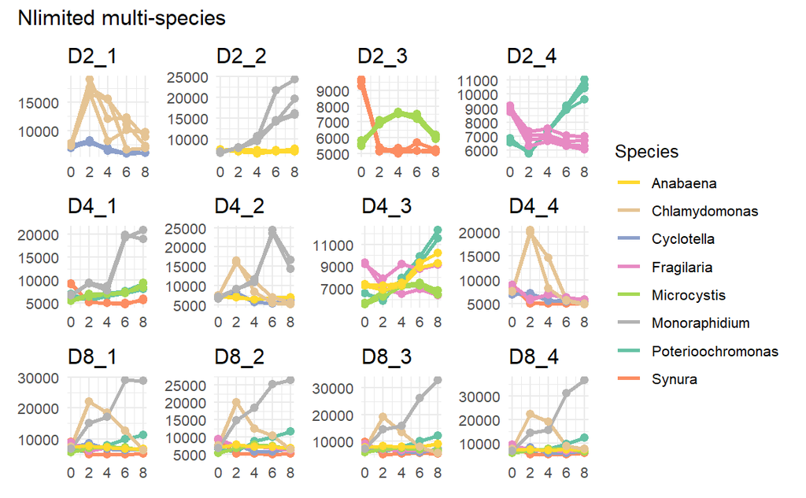

```r
draw_multi_species(Nlimited_plots)&
  plot_annotation(
    title = "Nlimited multi-species"
  )
```

Nlimited case shows more complex results.

We may also worried that species do not interact to each other. If this is true, then the population curve would keep similar in all cases. We plot each curve for single species:

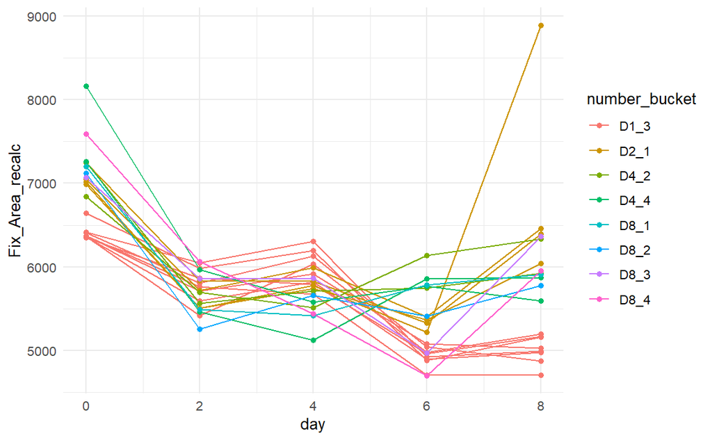

```r
ggplot(df[df$species==species[3] & df$nutrient_treatment=="N pulse",],aes(x = day, y = Fix_Area_recalc, group = paste(number_bucket, number_bag), colour = number_bucket))+
  geom_line()+
  geom_point()+
  theme_minimal()
```

Species shows similar change in each combinations, indicate the interactions might very weak.